# Blueprint simulator

## Description

A script that simulates how long it takes to gather all blueprints using the old system with 3 weekly drops.

By default the simulation works based on previously observed probabilities which are:

- Common: 0.6
- Decent: 0.25
- Nifty: 0.1
- Splendid: 0.05

Script works as the following:

1. Draws a random blueprint based on tier probabilities (also called an attempt)
2. If that blueprint has already been collected, then recycle it, if not keep it inventory
3. **Spender strategy:**
   - Save up until get 7200 filaments (in order to buy any tier)
   - Buy a missing blueprint at random (any tier)
   - Reduce the amount of filament according to cost
   - Continue to buy blueprints if filaments are still greater than 7200.
   - If only one missing blueprint left then buy it
4. **Hoarder strategy:**
   - Saves up all filaments from each recycling
   - Calculate the total filament cost of remaining missing blueprints
   - If saved up filaments is equal or greater then the remaining cost for missing blueprints, then stop as you now can buy the remaining blueprints
5. Print out the number of attempts, time and filaments required (if saving up).

## Simulation conditions

A total of 528 blueprints ready to be claimed.

The number of blueprints claimable per week is 3.

The average time in hours it takes for claiming all blueprints in a week is estimated to be around 1 hour and 50 minutes.

The recycled yield is calculated as getting 25% back when recycled.

## Results

Ran using 1000 simulations per approach.

### Spender strategy

Average hours required: 1009

Average weeks required: 551

Average years required: 10.6

Average number of recycled blueprints: 1237

### Hoarder strategy

Average hours required: 872

Average weeks required: 476

Average years required: 9.2

Average number of recycled blueprints: 976

Average filament required for tipping point: 253K

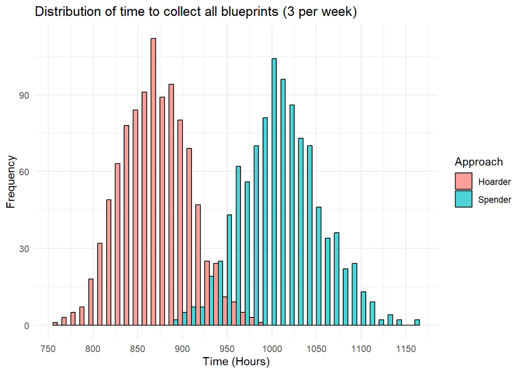

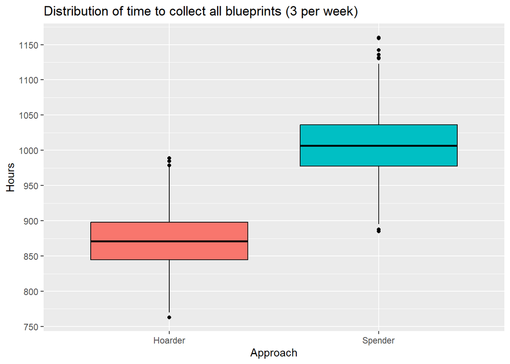

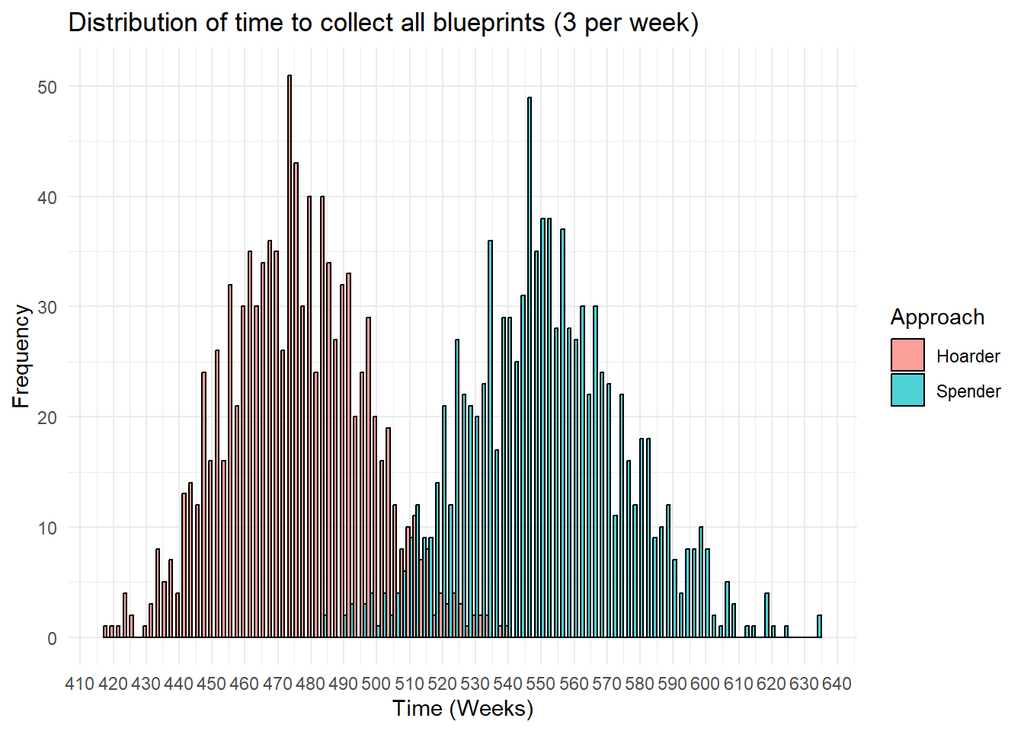

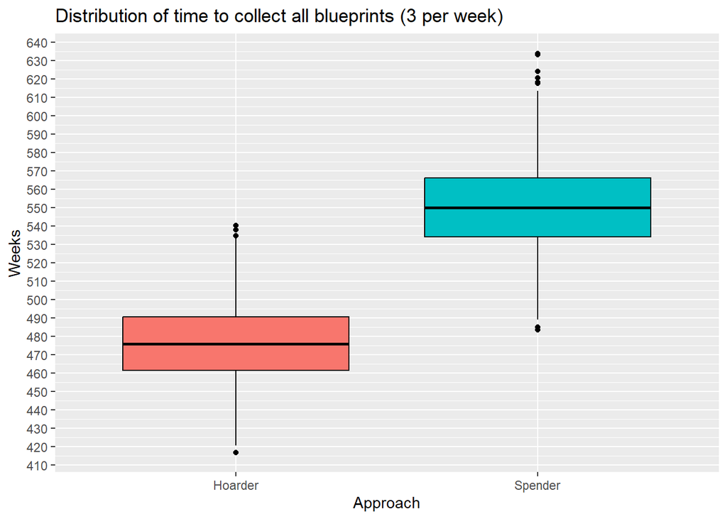

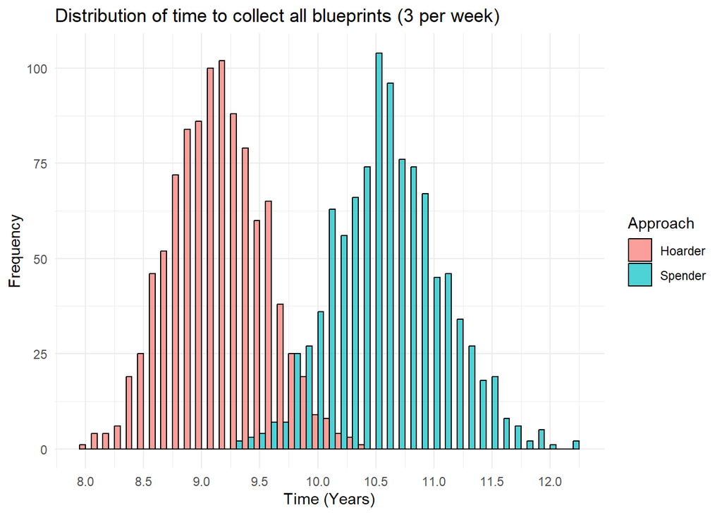

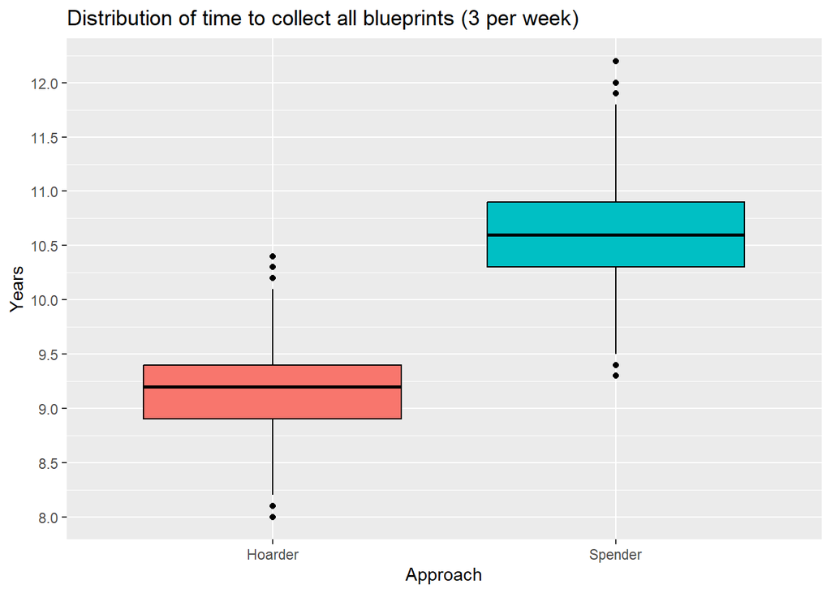

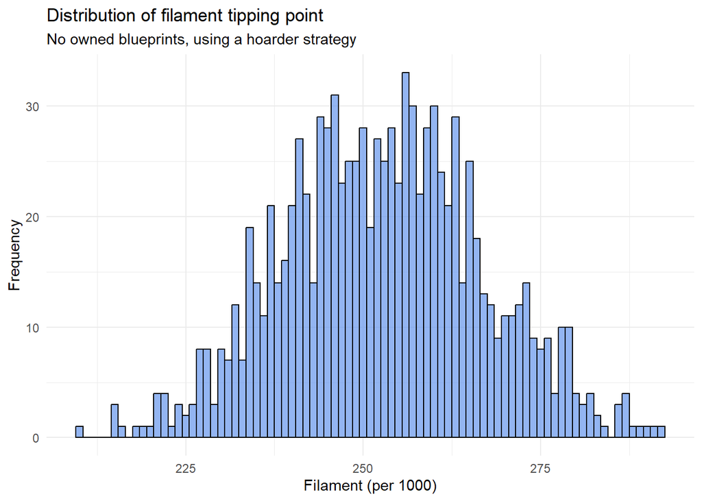

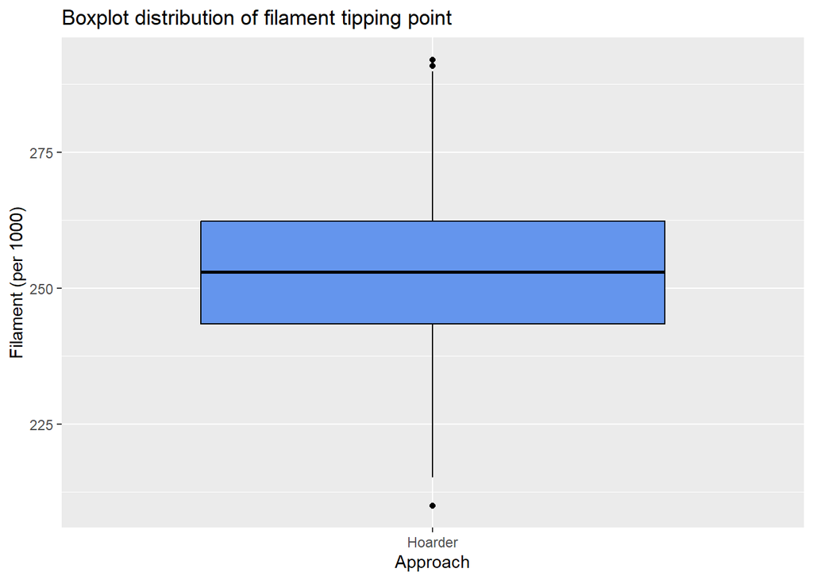